# Creating Maps using RNaturalEarth Data

Shefali C.

2022-05-24

This was one of the starter projects in my journey to learn/visualize and work with spatial data in R. The original work can be found [here](https://r-spatial.org/r/2018/10/25/ggplot2-sf.html). :)

The rmarkdown file starts with a generalised options function **`opts_chunk$set()`**. Here, all the parameters specified apply to all functions in the entire file.

For example, **`knitr::opts_chunk$set(fig.height=6, fig.width=6, fig.align='center')`** sets the height and width of all plots in the file to 6 by 6 with central alignment. Many more parameters can be added here to customize the entire file.

### Required libraries

In the following code, all the R packages required for this project are loaded.  
* **`tidyverse`-** is required for all the data manipulation tasks and contains **`ggplot`** package which is the foundation of all visualizations here.  
* **`sf`** package is required as the maps are sf objects.  
* **`rnaturalearth`** is required to fetch all the data.

```r
library(tidyverse)
library(sf)
library(rnaturalearth)
library(rnaturalearthdata)
library(ggspatial)
```

The following code:  
* sets the theme of all plots to black and white theme through function **`theme_bw()`**. One can easily override this theme by specifying another theme in a plot.  
* **`sf_use_s2(FALSE)`-** Initially in the map, the x-axis was not representing the longitudes properly; there were only 3 values like 0 degree, 90 degree, 180 etc. I wanted to add more degrees in between like 30, 60 etc. Setting this function as “FALSE” did this job.  
*Found this tip on stack overflow.*

```r
#setting the theme to theme_bw()
theme_set(theme_bw())
sf::sf_use_s2(FALSE)
```

```
Spherical geometry (s2) switched off
```

In the following code, data about all countries in the world is fetched from the **rnaturalearth** package.  
* Data of 241 countries is present in this package.  
* **`ne_countries()`** function is used to fetch this data.  
* **`returnclass`** has been specified as **“sf”**. There are 2 options available for this argument- **“sp”** & **“sf”**.  
* scale has been set to **medium**. 3 options are available- **“small”**, **“medium”** and **“large”**. This controls the size of the plot. For setting the value to **“large”**, loading package **`rnaturalearthhires`** is required. Why?? I don’t know yet.

```r
#fetching countries data
world <- rnaturalearth::ne_countries(returnclass = "sf", scale = "medium")
```

Instead of explicitly setting theme elements like size of axis titles, size and alignment of plot title etc. in every code snippet, these terms have been generated and stored in **theme_size**.

```r
#setting the size of xlabels, ylabels,title,subtitle to be reused in every plot
theme_size = theme(axis.title = element_text(size = 9),
                   plot.title = element_text(size = 11, hjust = 0.5),
                   plot.subtitle = element_text(size = 10,hjust = 0.5))
```

### World Map: Projection WGS84

Following are some versions of World map.  
* The Basic map is in its very basic form, with no labels or colors.  
* In the second map, countries have been colored on the basis of **estimated population variable `pop_est`** present in the dataframe.

#### Basic

- **`world`** object is actually a **“sf”** object; hence **`geom_sf()`** function has been used.
- **`color = "black"`** sets the boundary color of each country to black.
- **`size = 0.3`** controls the size of the boundary. Since the map is too compact, hence I have kept the size as 0.3 to prevent thick boundaries.
- **`world$name`** attribute means the **name** variable in **data** object. It contains the name of all countries.

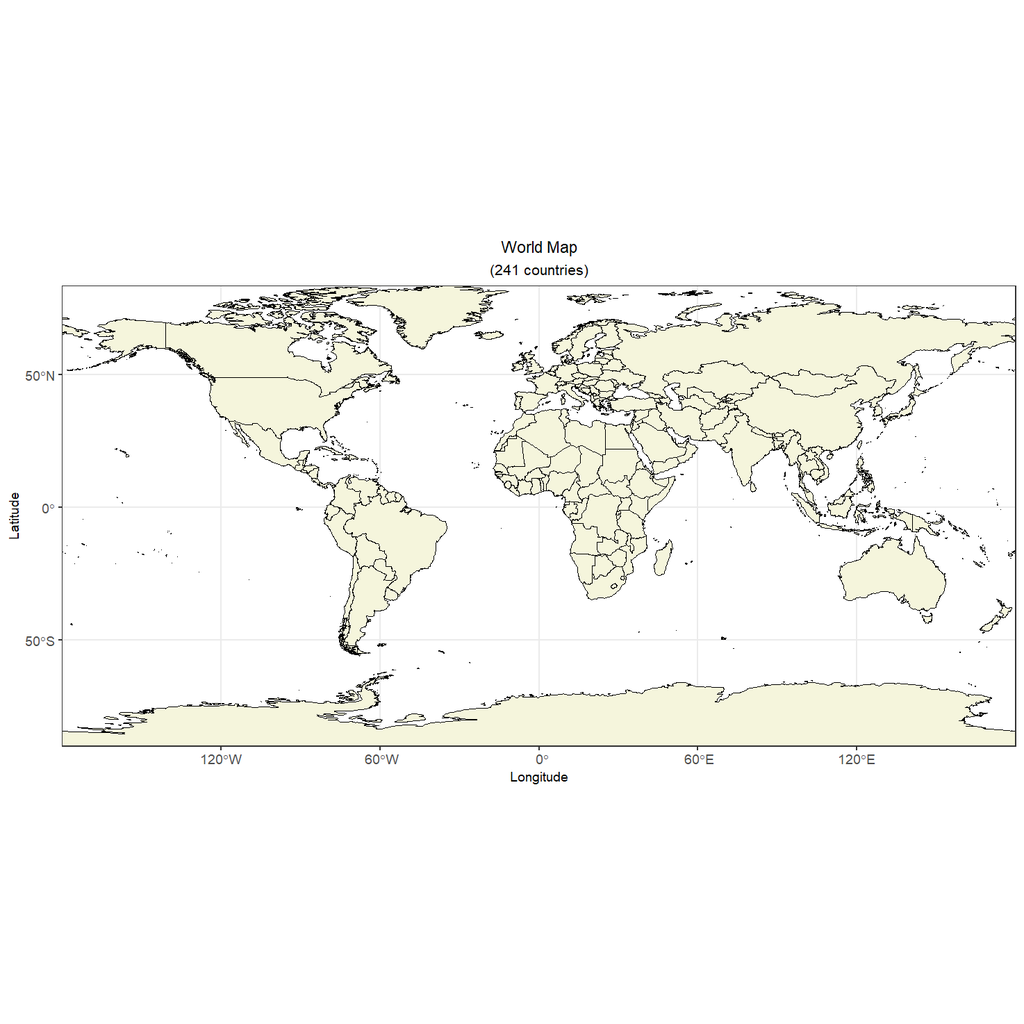

```r
#plotting basic world map
ggplot(data = world)+
  geom_sf(color = "black", size = 0.3, fill = "beige") +
  coord_sf(expand = FALSE)+
  labs(x = "Longitude",
       y = "Latitude",
      title = "World Map",
      subtitle = paste0("(",length(unique(world$name))," countries)"))+
  theme_size
```

#### Colored

- **`fill = pop_est`** colors each country according to the population of that country.
- **`coord_sf(expand=false)`-** By default, **`geom_Sf()`** function has the `coord_sf()` function in it. But I have explicitly mentioned it here, so that the spacing between the actual plot and axis lines gets omitted.
  - `expand = true` adds a little distortion in the grid values so that some space gets added between the map and grids.
  - `expand = false` removes that space and map fully covers the plot.
- **`scale_fill_viridis_c`** provides some really cool color palettes like *plasma, inferno, viridis* etc.

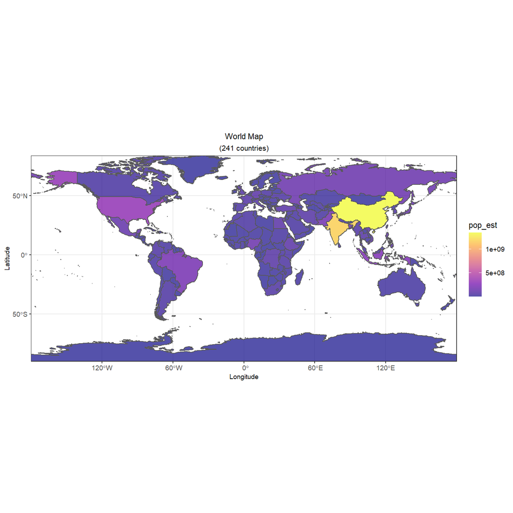

```r
#world map plot with color gradients representing estimated population
ggplot(data = world)+
  geom_sf(aes(fill = pop_est))+
  coord_sf(expand = FALSE)+
  scale_fill_viridis_c(option = "plasma",alpha = 0.7)+
  labs(x = "Longitude",
       y = "Latitude",
       title = "World Map",
       subtitle = paste0("(",length(unique(world$name))," countries)"))+
  theme_size
```

### Methods of Specifying projections

Projection of any map can be set in many ways.  
* In method 1, **`coord_sf(crs = "+init=epsg:3035)`** has been used. As the warning states, this syntax has been deprecated. :| * In method 2, **`coord_sf(crs = st_crs(3035))`** has been used.

#### Method 1

```
Warning in CPL_crs_from_input(x) :
  GDAL Message 1: +init=epsg:XXXX syntax is deprecated. It might return a CRS with a non-EPSG compliant axis order.
```

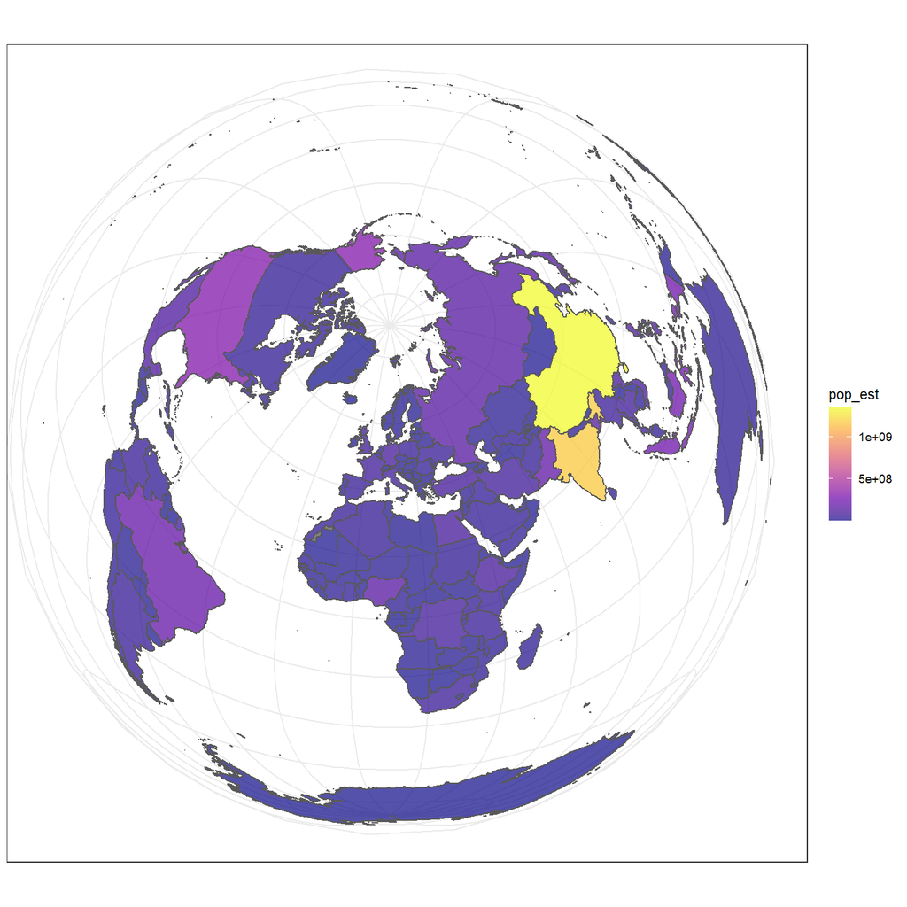

```r
#modifying the projection of the plot as:
#European-centric ETRS89 Lambert Azimuthal Equal-Area
ggplot(data = world)+
  geom_sf(aes(fill = pop_est))+
  scale_fill_viridis_c(option = "plasma",alpha = 0.7)+
  coord_sf(crs = "+init=epsg:3035")
```

#### Method 2

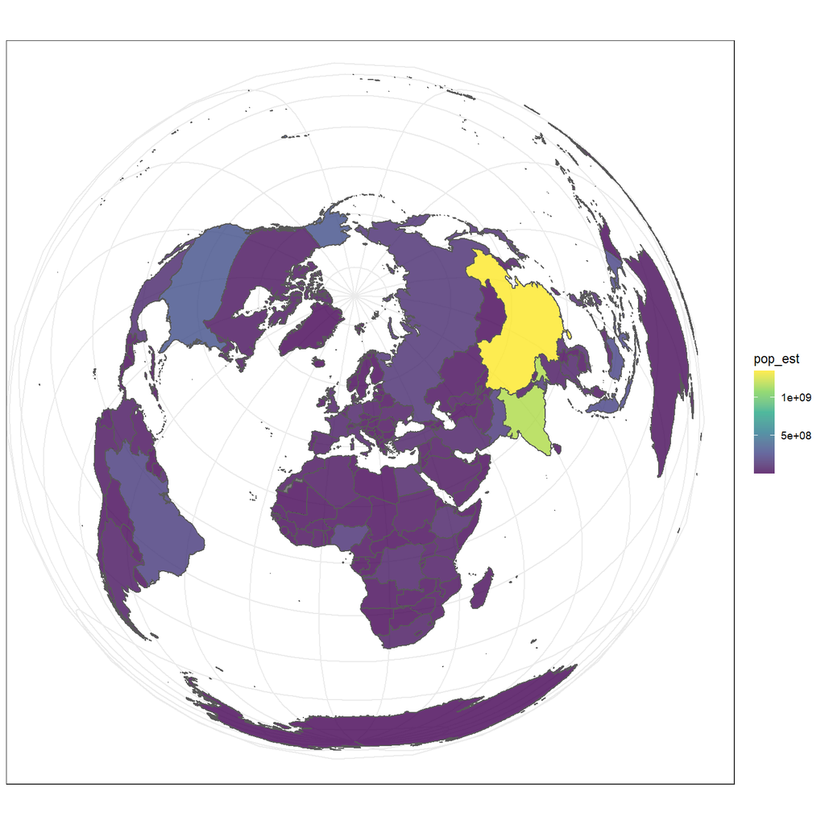

```r
#Another way to specify CRS using st_crs()
ggplot(data = world)+
  geom_sf(aes(fill=pop_est))+
  scale_fill_viridis_c(option = "viridis",alpha = 0.8)+
  coord_sf(crs = st_crs(3035))
```

### Map of India

I have zoomed into the map of India using the spatial extent of the Indian territory, i.e. the coordinates extent of latitudes and longitudes.

#### Simple Map

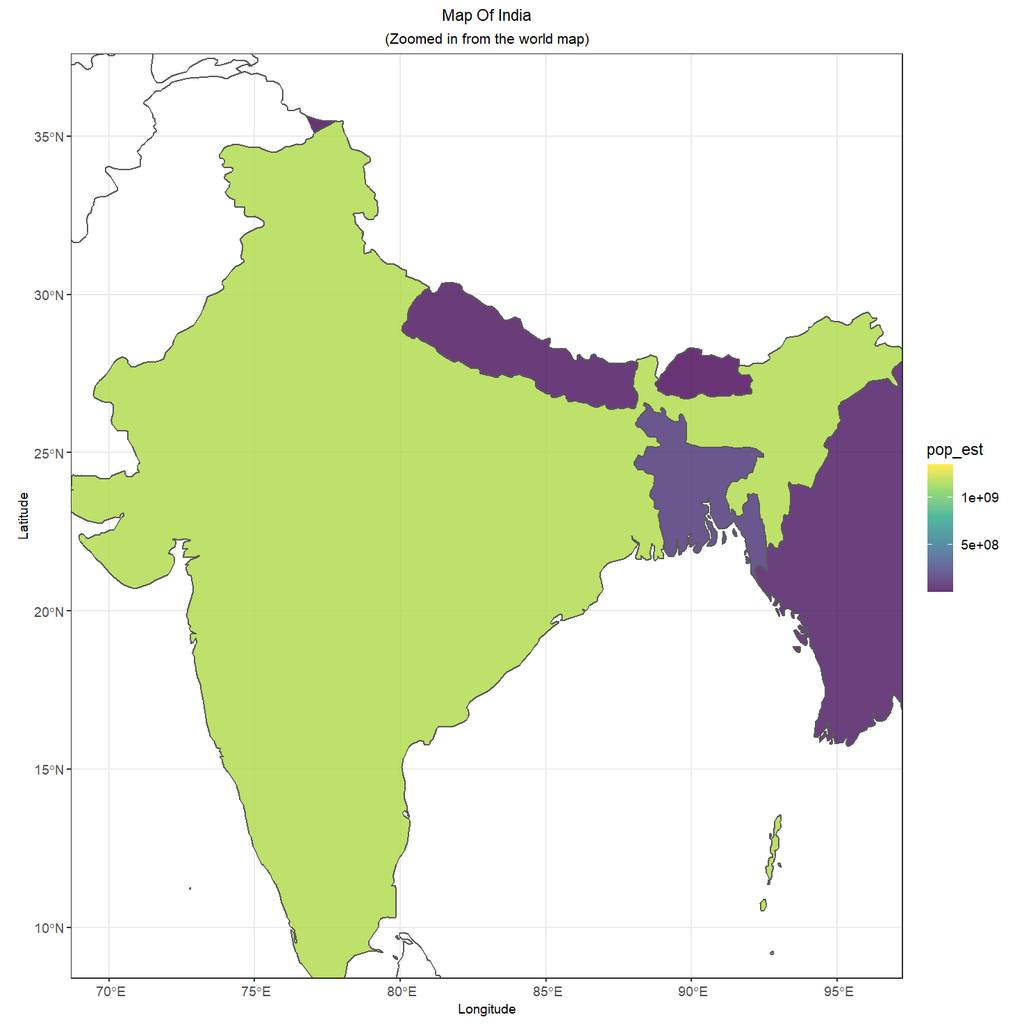

```r
#Zooming on the map of India
ggplot(data = world)+
  geom_sf(aes(fill = pop_est))+
  coord_sf(xlim = c(68.7,97.25), ylim = c(8.4,37.6), expand = FALSE)+
  scale_fill_viridis_c(option = "viridis",alpha=0.8)+
  labs(x = "Longitude",
       y = "Latitude",
       title = "Map Of India",
       subtitle = "(Zoomed in from the world map)")+
  theme_size
```

#### Map with labels

- **`st_centroid()`-** This function of **sf** package fetches the centroid of all countries in the world object.
- **`st_coordinates()`-** This function fetches the x and y coordinates of the centroid obtained for each country. After this, these X and Y columns are attached to the world object using **`cbind()`** function.

```r
#following 2 lines fetch the coordinates of the centroid of each country.
country_centroid <- sf::st_centroid(world)
country_centroid <- cbind(world, sf::st_coordinates(st_centroid(world$geometry)))
```

- The **`geom_text()`** function takes **`country_centroids`** as the dataframe; and attaches **name** of each country as label at the position of this centroid. So in a nutshell, centroids have been extracted to get the position within each country for the labels.
- **`annotate()`** just adds another layer with extra labels like “Bay of Bengal”.
- **`annotation_scale()`** adds the black and white distance scale that you see at the bottom of the map.
- **`annotation_north_arrow()`** adds the compass arrow. These layers can be added to make the maps more aesthetically pleasing. 🙂
- In the **`theme()`** function:
  - **panel.grid.major** adds the dashed grid lines in the background.
  - **panel.background** makes the background of the map, which is oceans here, of *aliceblue* color.

```
Scale on map varies by more than 10%, scale bar may be inaccurate
```

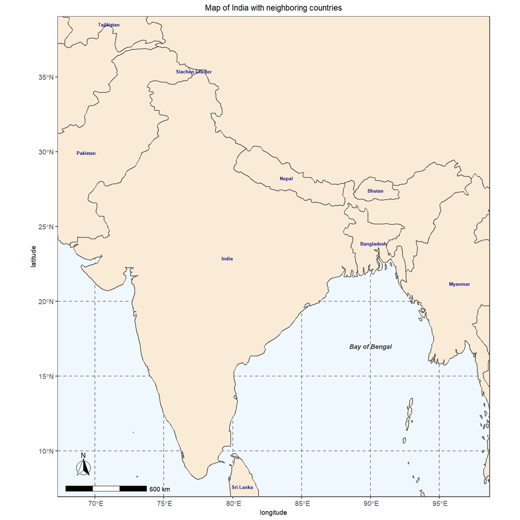

```r
#plot of India and neighboring countries with labels.
ggplot(data = world)+
  geom_sf(fill="antiquewhite")+
  geom_text(data = country_centroid,aes(x=X,y=Y,label=name),
            color="darkblue",fontface="bold",check_overlap = FALSE,size=2.2)+
  annotate(geom="text",x=90,y=17,label="Bay of Bengal",fontface="bold.italic",
           color="gray22",size=3)+
  annotation_scale(location="bl",width_hint=0.2,pad_x = unit(0.15,"in"))+
  annotation_north_arrow(location="bl",which_north="true",
                         pad_x = unit(0.25,"in"),pad_y=unit(0.35,"in"),
                         style = north_arrow_fancy_orienteering,
                         height = unit(0.45,"in"),
                         width = unit(0.45,"in"))+
  coord_sf(xlim = c(68.7,97.25), ylim = c(8.4,37.6), expand = TRUE)+
  labs(x="longitude",y="latitude",
       title = "Map of India with neighboring countries")+
  theme_size+
  theme(panel.grid.major = element_line(color = grey(0.5),linetype="dashed",
                                        size=0.5),
        panel.background = element_rect(fill = "aliceblue"))
```